# Meridian Open University: Board Review

The R five: Aarsee, Divyanshi, Jatin, Chaarvi, Anubhav

2026-09-28

# Part A: Introduction

## 1. Business context

Meridian Open University is a distance-learning provider. Students enroll in individual modules, study remotely, and interact with the university almost entirely through a virtual learning environment (VLE), where every click is logged.

Roughly a third of registrations end in withdrawal. This has long been treated as the price of the university’s access mission. The Board has asked:

> “Based on everything in this data, what kind of institution are we, and what should that tell us about where to focus in 2016?”

This report answers that question from the present data (not a forecast or an early-warning model) by examining who enrols, how students engage, and where outcomes are healthy or failing.

### Analysis objectives

To answer the Board, the analysis works through six questions in order. Each part of the report answers one of them:

1. **Can the data be trusted?** Check keys, links and missing values, then clean and combine the seven tables into one (Parts B to D).
2. **Who enrols, and does it matter?** Profile the students and test which background factors are linked to results (Part E).
3. **Where and when do students leave?** Compare modules and years, and find when withdrawals happen (Part F).
4. **How do healthy and troubled students behave?** Compare clicks and assessment behaviour (Parts G and H).
5. **Where is the problem concentrated?** Group students by what they did and find where the non-completers sit (Part I).
6. **Is anything hidden in the official figures?** Use the click data to find students who stopped taking part without withdrawing (Part J, our innovation).

The report ends with the answer to the Board and our recommendations for 2016.

## 2. Data loading

```r
# WHAT THIS CHUNK DOES: Load the packages (toolboxes) the whole report uses
# Hide package and file-reading messages in the report
knitr::opts_chunk$set(message = FALSE, warning = FALSE)

# Load the packages we need
library(tidyverse)   # data handling and charts
library(data.table)  # fast file reading for the big click file
library(scales)      # nicer percentage labels on charts
library(knitr)       # neat tables in the html report
```

```r
# WHAT THIS CHUNK DOES: Read the 7 data files into R and count their rows
# Read the six smaller tables
studentInfo         <- read_csv("Data/studentInfo.csv")
studentRegistration <- read_csv("Data/studentRegistration.csv")
courses             <- read_csv("Data/courses.csv")
assessments         <- read_csv("Data/assessments.csv")
studentAssessment   <- read_csv("Data/studentAssessment.csv")
vle                 <- read_csv("Data/vle.csv")

# The click file is very large, so we use fread, which is much faster
studentVle <- fread("Data/studentVle.csv")

# Check how many rows and columns each table has
tibble(
  table = c("studentInfo", "studentRegistration", "courses", "assessments",
            "studentAssessment", "vle", "studentVle"),
  rows  = c(nrow(studentInfo), nrow(studentRegistration), nrow(courses),
            nrow(assessments), nrow(studentAssessment), nrow(vle), nrow(studentVle))
)
```

```
## # A tibble: 7 × 2
##   table                   rows
##   <chr>                  <int>
## 1 studentInfo            32593
## 2 studentRegistration    32593
## 3 courses                   22
## 4 assessments              206
## 5 studentAssessment     173912
## 6 vle                     6364
## 7 studentVle          10655280
```

All seven tables loaded; the row count of each is shown in the table above.

# Part B: Checking the keys, links, and missing values

## 3. Data quality checks

```r
# WHAT THIS CHUNK DOES: Check the data can be trusted: unique IDs, working links, missing values
# The three columns that identify one student in one module-run
k3 <- c("code_module", "code_presentation", "id_student")

# A small helper: TRUE if the given columns uniquely identify every row
is_unique <- function(df, cols) nrow(distinct(df, across(all_of(cols)))) == nrow(df)

# 1. Primary key checks
tibble(
  table = c("studentInfo", "studentRegistration", "courses",
            "assessments", "studentAssessment", "vle"),
  key   = c("module + presentation + student", "module + presentation + student",
            "module + presentation", "id_assessment",
            "id_assessment + id_student", "id_site"),
  unique = c(is_unique(studentInfo, k3),
             is_unique(studentRegistration, k3),
             is_unique(courses, c("code_module", "code_presentation")),
             is_unique(assessments, "id_assessment"),
             is_unique(studentAssessment, c("id_assessment", "id_student")),
             is_unique(vle, "id_site"))
) %>% kable(caption = "Primary key checks")
```

Primary key checks

| table | key | unique |
| --- | --- | --- |
| studentInfo | module + presentation + student | TRUE |
| studentRegistration | module + presentation + student | TRUE |
| courses | module + presentation | TRUE |
| assessments | id_assessment | TRUE |
| studentAssessment | id_assessment + id_student | TRUE |
| vle | id_site | TRUE |

```r
# 2. Link checks: how many rows fail to find a match (0 = all linked)
tibble(
  link = c("studentRegistration -> studentInfo",
           "studentInfo -> courses",
           "assessments -> courses",
           "vle -> courses",
           "studentAssessment -> assessments",
           "studentVle -> vle",
           "studentVle -> studentInfo"),
  unmatched_rows = c(nrow(anti_join(studentRegistration, studentInfo, by = k3)),
                     nrow(anti_join(studentInfo, courses,
                                    by = c("code_module", "code_presentation"))),
                     nrow(anti_join(assessments, courses,
                                    by = c("code_module", "code_presentation"))),
                     nrow(anti_join(vle, courses,
                                    by = c("code_module", "code_presentation"))),
                     sum(!studentAssessment$id_assessment %in% assessments$id_assessment),
                     sum(!studentVle$id_site %in% vle$id_site),
                     nrow(anti_join(as_tibble(unique(studentVle[, ..k3])),
                                    studentInfo, by = k3)))
) %>% kable(caption = "Link checks")
```

Link checks

| link | unmatched_rows |
| --- | --- |
| studentRegistration -> studentInfo | 0 |
| studentInfo -> courses | 0 |
| assessments -> courses | 0 |
| vle -> courses | 0 |
| studentAssessment -> assessments | 0 |
| studentVle -> vle | 0 |
| studentVle -> studentInfo | 0 |

```r
# 3. Missing values in each table (only columns with at least one gap)
list(studentInfo = studentInfo, studentRegistration = studentRegistration,
     courses = courses, assessments = assessments,
     studentAssessment = studentAssessment, vle = vle) %>%
  map_dfr(~ tibble(column = names(.x), missing = colSums(is.na(.x))), .id = "table") %>%
  filter(missing > 0) %>%
  kable(caption = "Missing values")
```

Missing values

| table | column | missing |
| --- | --- | --- |
| studentInfo | imd_band | 1111 |
| studentRegistration | date_registration | 45 |
| studentRegistration | date_unregistration | 22521 |
| assessments | date | 11 |
| studentAssessment | score | 173 |
| vle | week_from | 5243 |
| vle | week_to | 5243 |

All primary keys are unique and all seven links checked above match, so the tables can be joined safely. Note that id_student alone is not unique: some students appear in more than one module-run, so joins always use module, presentation and student together.

Missing values and how we treat them:

- **imd_band (1,111 missing):** kept as a separate “Unknown” group rather than dropped.
- **date_registration (45 missing):** left as missing; these students are kept.
- **date_unregistration (22,521 missing):** almost all students who did not withdraw have no date here (10,063 of 10,156 withdrawn students have a date), so a blank is read as “did not unregister”. Only 9 students who did not withdraw have a date; they are left as they are.
- **Assessment date (11 missing):** all 11 are Exams. As stated in the case, a null exam date means the end of the presentation, so we fill it with the module length.
- **score (173 missing):** submissions with no recorded score; excluded from score averages.
- **is_banked (1,909 rows = 1):** results carried over from an earlier presentation. They still count as submitted, but their submission date belongs to the earlier run, so they are left out of every “late” / “on time” check.
- **week_from / week_to (5,243 missing):** not used in this analysis.

# Part C: Clean the data

## 4. Data cleaning

```r
# WHAT THIS CHUNK DOES: Fix messy labels, fill blank exam dates, and order categories for charts
# Clean the student table
studentInfo_clean <- studentInfo %>%
  mutate(
    # One band is written "10-20" without the % sign; make it consistent
    imd_band = recode(imd_band, "10-20" = "10-20%"),
    # Keep missing deprivation as its own group
    imd_band = replace_na(imd_band, "Unknown"),
    imd_band = factor(imd_band, levels = c("0-10%", "10-20%", "20-30%", "30-40%",
                                           "40-50%", "50-60%", "60-70%", "70-80%",
                                           "80-90%", "90-100%", "Unknown")),
    # Put categories in a sensible order for charts
    age_band = factor(age_band, levels = c("0-35", "35-55", "55<=")),
    highest_education = factor(highest_education,
                               levels = c("No Formal quals", "Lower Than A Level",
                                          "A Level or Equivalent", "HE Qualification",
                                          "Post Graduate Qualification")),
    final_result = factor(final_result,
                          levels = c("Distinction", "Pass", "Fail", "Withdrawn")),
    # A simple two-group version of the outcome (TRUE = Distinction or Pass)
    completed_flag = final_result %in% c("Distinction", "Pass")
  )

# Fill the 11 blank exam dates with the module length (end of presentation)
assessments_clean <- assessments %>%
  left_join(courses, by = c("code_module", "code_presentation")) %>%
  mutate(date = if_else(is.na(date) & assessment_type == "Exam",
                        module_presentation_length, date))

# Quick check: overall outcome split
studentInfo_clean %>%
  count(final_result) %>%
  mutate(share = percent(n / sum(n), accuracy = 0.1)) %>%
  kable(caption = "Final results across all registrations")
```

Final results across all registrations

| final_result | n | share |
| --- | --- | --- |
| Distinction | 3024 | 9.3% |
| Pass | 12361 | 37.9% |
| Fail | 7052 | 21.6% |
| Withdrawn | 10156 | 31.2% |

Cleaning steps: the “10-20” deprivation band was relabeled “10-20%” for consistency; missing deprivation was set to “Unknown”; categories were put in a logical order for charts; the 11 blank exam dates were set to the module length; and a two-group completed / not completed flag was added (completed = Distinction or Pass).

Only 47.2% of registrations end in completion. Withdrawal (31.2%) is the single largest non-completion outcome, and a further 21.6% fail.

**Interpretations** (not stated in the data or case):

- Day 0 is taken as the module start date; negative days are before the start.
- The education levels are ordered from lowest to highest by their names.
- The 0-10% deprivation band is read as the most deprived; the data does not state the direction, but this band has the lowest completion.

# Part D : Combine the data

## 5. Building the student-level master table

```r
# WHAT THIS CHUNK DOES: Build one big table: one row per student per module, with their clicks and assignments
# ---- A. Summarise the click log to one row per student per module-run ----
# data.table syntax is used here because studentVle has 10.6 million rows
vle_summary <- studentVle[, .(
  total_clicks         = sum(sum_click),
  active_days          = uniqueN(date),
  last_active_day      = max(date),
  clicks_before_start  = sum(sum_click[date < 0]),
  clicks_first_14_days = sum(sum_click[date >= 0 & date < 14])
), by = .(code_module, code_presentation, id_student)] %>%
  as_tibble()

# ---- B. Summarise assessments (non-exam only) ----
non_exam <- assessments_clean %>% filter(assessment_type != "Exam")

# How many non-exam assessments each module-run has
available <- non_exam %>%
  count(code_module, code_presentation, name = "n_assess_available")

# The first assessment of each module-run (earliest date)
first_assess <- non_exam %>%
  arrange(code_module, code_presentation, date, id_assessment) %>%
  group_by(code_module, code_presentation) %>%
  slice(1) %>%
  ungroup() %>%
  select(code_module, code_presentation, id_assessment)

# Attach module, presentation and due date to every submission
subs <- studentAssessment %>%
  inner_join(non_exam %>% select(id_assessment, code_module,
                                 code_presentation, due_date = date),
             by = "id_assessment") %>%
  # Banked results were submitted in an earlier run, so their date cannot be
  # compared with this run's due date: never count them as late
  mutate(is_late = is_banked == 0 & date_submitted > due_date)

# One row per student: how many submitted, average score, how many late
assess_summary <- subs %>%
  group_by(code_module, code_presentation, id_student) %>%
  summarise(n_submitted = n(),
            n_timed     = sum(is_banked == 0),   # submissions whose timing can be judged
            avg_score   = mean(score, na.rm = TRUE),
            n_late      = sum(is_late, na.rm = TRUE),
            .groups = "drop")

# Which students submitted their module's first assessment
first_sub <- subs %>%
  semi_join(first_assess,
            by = c("code_module", "code_presentation", "id_assessment")) %>%
  distinct(code_module, code_presentation, id_student) %>%
  mutate(submitted_first = TRUE)

# ---- C. Join everything onto the student table ----
master <- studentInfo_clean %>%
  left_join(studentRegistration, by = k3) %>%
  left_join(courses, by = c("code_module", "code_presentation")) %>%
  left_join(vle_summary, by = k3) %>%
  left_join(available, by = c("code_module", "code_presentation")) %>%
  left_join(assess_summary, by = k3) %>%
  left_join(first_sub, by = k3) %>%
  mutate(
    # No rows in the click log or submissions = zero activity
    across(c(total_clicks, active_days, clicks_before_start,
             clicks_first_14_days, n_submitted, n_timed, n_late), ~ replace_na(.x, 0)),
    submitted_first = replace_na(submitted_first, FALSE),
    submit_rate     = n_submitted / n_assess_available,
    never_clicked   = total_clicks == 0
  )

# Check: still one row per student per module-run?
nrow(master)
```

```
## [1] 32593
```

```r
# First look: how the four outcome groups differ
master %>%
  group_by(final_result) %>%
  summarise(students            = n(),
            median_clicks       = median(total_clicks),
            median_active_days  = median(active_days),
            median_clicks_first_14_days = median(clicks_first_14_days),
            pct_never_clicked   = percent(mean(never_clicked), 0.1),
            avg_submit_rate     = percent(mean(submit_rate), 0.1),
            avg_score           = round(mean(avg_score, na.rm = TRUE), 1),
            pct_submitted_first = percent(mean(submitted_first), 0.1)) %>%
  kable(caption = "How the four outcome groups differ")
```

How the four outcome groups differ

| final_result | students | median_clicks | median_active_days | median_clicks_first_14_days | pct_never_clicked | avg_submit_rate | avg_score | pct_submitted_first |
| --- | --- | --- | --- | --- | --- | --- | --- | --- |
| Distinction | 3024 | 1896 | 103 | 144 | 0.0% | 96.8% | 88.4 | 99.8% |
| Pass | 12361 | 1343 | 78 | 97 | 0.0% | 95.6% | 76.5 | 99.0% |
| Fail | 7052 | 317 | 22 | 37 | 5.3% | 44.6% | 64.6 | 79.2% |
| Withdrawn | 10156 | 89 | 7 | 11 | 29.4% | 15.5% | 64.1 | 44.8% |

The seven tables are now combined into one master table: 32,593 rows, one per student per module-run. Click activity and assessment behaviour have been summarised for each student. Exams are excluded from the assessment summary because exam scores are recorded for only some modules.

This first comparison already shows a very large gap between the groups:

- **Completers are heavily engaged.** A typical Pass student made 1,343 clicks on 78 different days and submitted about 96% of assessments.
- **Withdrawn students barely engaged at all.** The typical withdrawn student clicked on only 7 days, and 29.4% never clicked once.
- **Failing students look more like withdrawn students than passing ones.** They submitted on average only 44.6% of their assessments, but when they did submit, they averaged 64.6, compared with 76.5 for Pass students. The gap in whether they submit is much larger than the gap in how well they score.

The sections that follow examine each of these patterns in more detail.

# Part E1: Add grouping columns and a chart color scheme

## 6. Who enrolls, and does it matter?

```r
# WHAT THIS CHUNK DOES: Group credits and repeat attempts, and fix one colour per result for all charts
# Group credits and previous attempts into simple categories
master <- master %>%
  mutate(
    credit_group  = cut(studied_credits, breaks = c(0, 60, 120, Inf),
                        labels = c("60 or less", "61-120", "More than 120")),
    attempt_group = if_else(num_of_prev_attempts > 0, "Repeat", "First attempt")
  )

# One fixed colour per outcome, used in every chart
outcome_colours <- c("Distinction" = "#1b7837", "Pass" = "#7fbf7b",
                     "Fail" = "#f4a582", "Withdrawn" = "#b2182b")
```

# Part E2: Profile of who enrolls

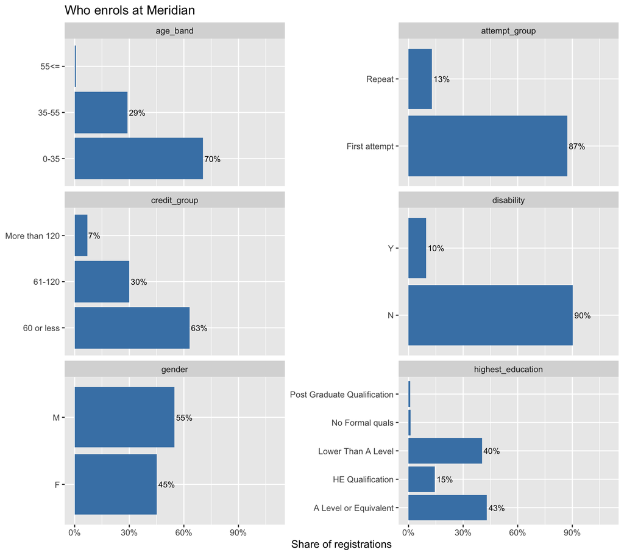

```r
# WHAT THIS CHUNK DOES: Chart who signs up (age, education, credits, and so on)
master %>%
  select(gender, age_band, highest_education, disability,
         credit_group, attempt_group) %>%
  mutate(across(everything(), as.character)) %>%
  pivot_longer(everything(), names_to = "characteristic", values_to = "group") %>%
  count(characteristic, group) %>%
  group_by(characteristic) %>%
  mutate(share = n / sum(n)) %>%
  ggplot(aes(x = share, y = group)) +
  geom_col(fill = "steelblue") +
  geom_text(aes(label = if_else(share >= 0.04, percent(share, 1), "")), hjust = -0.1, size = 3) +
  facet_wrap(~ characteristic, scales = "free_y", ncol = 2) +
  scale_x_continuous(labels = percent, limits = c(0, 1.1)) +
  labs(title = "Who enrols at Meridian", x = "Share of registrations", y = NULL)
```

**Who enrols.** The typical registration is a first attempt (87.2%) by someone under 35 (70.4%) with A level or lower education (84.6%), taking 60 credits or less (63.1%). 54.8% are men and 9.7% declare a disability. Only 6.9% take more than 120 credits, and 12.8% are repeating the module.

**Business meaning:** Meridian mainly serves younger adults without a degree who are taking a light study load. This is the access mission in action. Parts E3 and E4 test whether these characteristics are actually linked to results.

# Part E3: How outcomes differ by group

```r
# WHAT THIS CHUNK DOES: A reusable function that draws "results by group" for any column
# Draws a stacked bar of final results for any student characteristic
plot_outcome <- function(var, label) {
  master %>%
    count({{ var }}, final_result) %>%
    group_by({{ var }}) %>%
    mutate(share = n / sum(n)) %>%
    ungroup() %>%
    ggplot(aes(x = {{ var }}, y = share, fill = final_result)) +
    geom_col() +
    geom_text(aes(label = percent(share, 1)),
              position = position_stack(vjust = 0.5), size = 3) +
    coord_flip() +
    scale_y_continuous(labels = percent) +
    scale_fill_manual(values = outcome_colours) +
    labs(title = paste("Final result by", label),
         x = NULL, y = "Share of registrations", fill = "Final result")
}
```

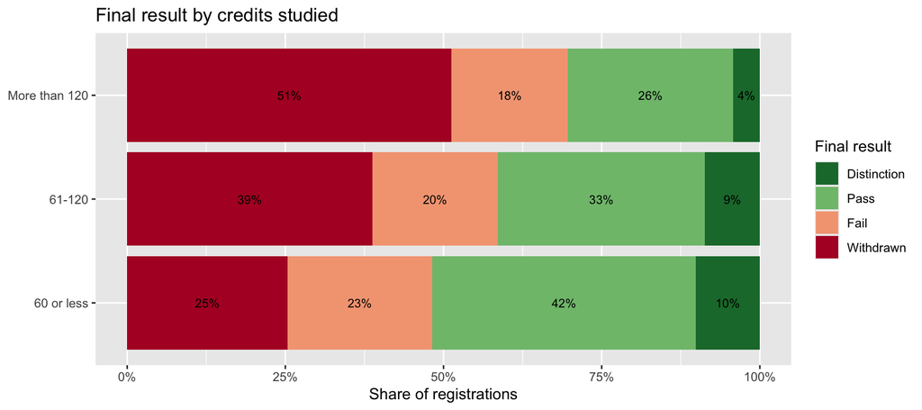

```r
# WHAT THIS CHUNK DOES: Results by credits, education, deprivation and repeat attempts
plot_outcome(credit_group, "credits studied")
```

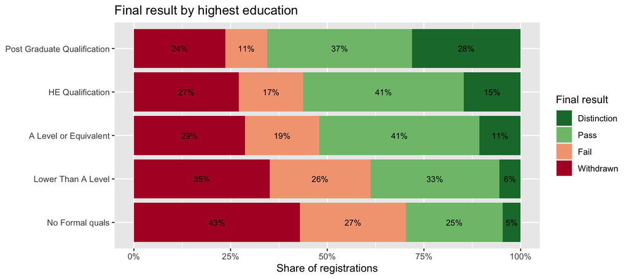

```r
plot_outcome(highest_education, "highest education")
```

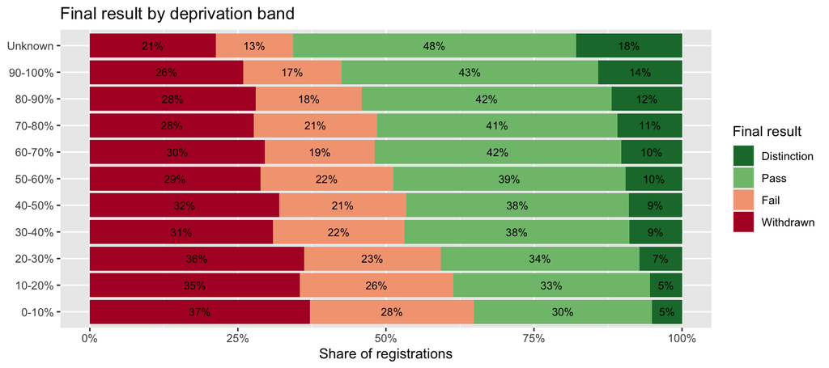

```r
plot_outcome(imd_band, "deprivation band")
```

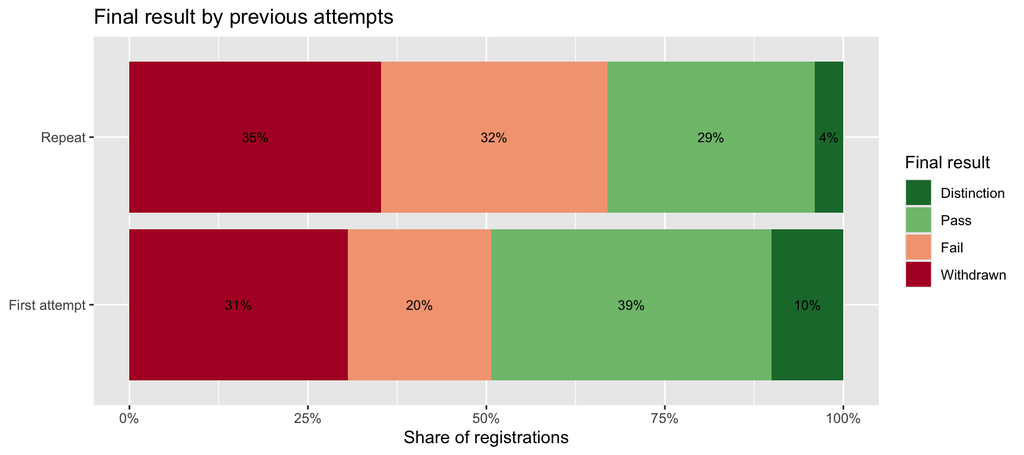

```r
plot_outcome(attempt_group, "previous attempts")
```

**Workload** shows the steepest pattern. Withdrawal rises from 25.4% among students taking 60 credits or less, to 38.7% at 61-120 credits, and 51.3% above 120 credits.

**Prior education** matters at both ends. Students with no formal qualifications withdraw at 42.9% compared with 23.6% for postgraduates, and distinctions rise from 4.6% to 28.1%.

**Deprivation** follows a steady gradient. Withdrawal falls from 37.2% in the 0-10% band to 25.9% in the 90-100% band, and distinctions rise from 5.1% to 14.1%.

**Repeat students** do worse. Among students on a repeat attempt, 31.7% fail and only 4.0% achieve a distinction, compared with 20.2% and 10.1% for first attempts.

# Part E4: Which characteristics matter most?

With 32,593 students, almost any difference will be “statistically significant,” even a tiny one. So we also calculate Cramér’s V, which measures how strong the relationship is on a scale from 0 (no relationship) to 1 (perfect). This lets you rank the factors fairly.

```r
# WHAT THIS CHUNK DOES: Test which background factors are linked to results, and how strongly (Cramer's V)
test_vars <- c("gender", "region", "age_band", "highest_education", "imd_band",
               "disability", "credit_group", "attempt_group", "code_module")

map_dfr(test_vars, function(v) {
  tab  <- table(master[[v]], master$final_result)
  test <- suppressWarnings(chisq.test(tab))
  tibble(characteristic = v,
         chi_square = round(unname(test$statistic), 1),
         df         = unname(test$parameter),
         p_value    = format.pval(test$p.value, digits = 2),
         cramers_v  = round(sqrt(unname(test$statistic) /
                                 (sum(tab) * (min(dim(tab)) - 1))), 3))
}) %>%
  arrange(desc(cramers_v)) %>%
  kable(caption = "Chi-square tests: characteristic vs final result")
```

Chi-square tests: characteristic vs final result

| characteristic | chi_square | df | p_value | cramers_v |
| --- | --- | --- | --- | --- |
| credit_group | 1046.1 | 6 | <2e-16 | 0.127 |
| attempt_group | 490.4 | 3 | <2e-16 | 0.123 |
| code_module | 1443.2 | 18 | <2e-16 | 0.121 |
| highest_education | 1024.7 | 12 | <2e-16 | 0.102 |
| imd_band | 858.9 | 30 | <2e-16 | 0.094 |
| region | 449.7 | 36 | <2e-16 | 0.068 |
| disability | 138.5 | 3 | <2e-16 | 0.065 |
| age_band | 222.7 | 6 | <2e-16 | 0.058 |
| gender | 16.5 | 3 | 0.00088 | 0.023 |

Every characteristic is statistically significant (all p-values below 0.001), which is expected with over 32,000 registrations. Cramér’s V shows how strong each relationship is. All the values are small (none is above 0.13), so each characteristic on its own is only weakly linked to outcomes. The top three (**credit load, repeat attempts and module**) are practically tied, followed by prior education and deprivation. **Gender has almost no relationship with outcomes** (V = 0.023).

This matters for the Board: two of the top three (how much a student takes on and which module they are on) are things the university can directly influence, rather than fixed facts about who the student is. The weak values also show that who a student is explains little on its own; what students do (Parts G and H) says far more.

# Part F1: Outcomes by module

## 7. Where and when: modules, trends and withdrawal timing

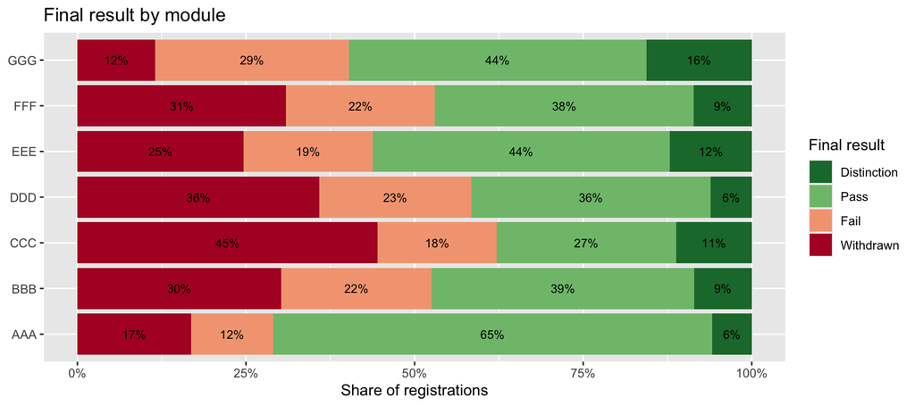

```r
# WHAT THIS CHUNK DOES: Results for each module (course)
plot_outcome(code_module, "module")
```

Outcomes vary sharply between modules. Withdrawal ranges from 11.5% in GGG and 16.8% in AAA up to 35.9% in DDD and 44.5% in CCC. CCC loses almost half of its registrations to withdrawal. The same student population produces very different results depending on the module, which suggests part of the problem sits in how specific modules are run, not only in who enrols.

# Part F2: Is it getting better or worse?

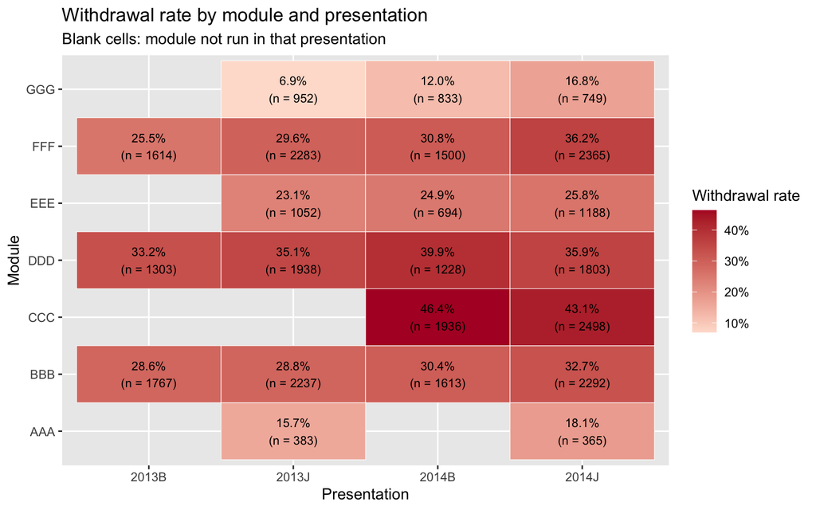

```r
# WHAT THIS CHUNK DOES: Quit rate for every module in every year, as a coloured grid
# Withdrawal rate for every module-run
master %>%
  group_by(code_module, code_presentation) %>%
  summarise(withdrawal_rate = mean(final_result == "Withdrawn"),
            students = n(), .groups = "drop") %>%
  ggplot(aes(x = code_presentation, y = code_module, fill = withdrawal_rate)) +
  geom_tile(colour = "white") +
  geom_text(aes(label = paste0(percent(withdrawal_rate, 0.1),
                               "\n(n = ", students, ")")), size = 3) +
  scale_fill_gradient(low = "#fee0d2", high = "#b2182b", labels = percent) +
  labs(title = "Withdrawal rate by module and presentation",
       subtitle = "Blank cells: module not run in that presentation",
       x = "Presentation", y = "Module", fill = "Withdrawal rate")
```

**Reading the heatmap.** Each square is one module in one presentation. The darkest squares are CCC in 2014B (46.4%) and 2014J (43.1%) and DDD in 2014B (39.9%); the lightest are GGG (6.9% in 2013J) and AAA (15.7% to 18.1%). In every module that ran in both years, the squares are darker in 2014 than in 2013.

**Business meaning:** the problem is not one bad run. A few modules are consistently weak and almost all are getting worse, so the university needs module-level reviews as well as support for individual students.

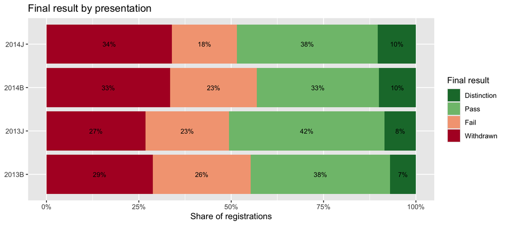

```r
# WHAT THIS CHUNK DOES: Results by year, plus a fair comparison using only modules that ran in both years
plot_outcome(code_presentation, "presentation")
```

```r
# Fair comparison: the module mix changed between years (CCC, the module with
# the highest withdrawal, only ran in 2014), so also compare using only the
# modules that ran in both 2013J and 2014J
both_years <- master %>%
  filter(code_presentation %in% c("2013J", "2014J")) %>%
  distinct(code_module, code_presentation) %>%
  count(code_module) %>%
  filter(n == 2) %>%
  pull(code_module)

bind_rows(
  master %>% filter(code_presentation %in% c("2013J", "2014J")) %>%
    mutate(comparison = "All modules"),
  master %>% filter(code_presentation %in% c("2013J", "2014J"),
                    code_module %in% both_years) %>%
    mutate(comparison = paste0("Same modules only (", paste(both_years, collapse = ", "), ")"))
) %>%
  group_by(comparison, code_presentation) %>%
  summarise(withdrawal_rate = percent(mean(final_result == "Withdrawn"), 0.1),
            .groups = "drop") %>%
  pivot_wider(names_from = code_presentation, values_from = withdrawal_rate) %>%
  kable(caption = "Withdrawal rate, 2013J vs 2014J")
```

Withdrawal rate, 2013J vs 2014J

| comparison | 2013J | 2014J |
| --- | --- | --- |
| All modules | 26.8% | 34.0% |
| Same modules only (AAA, BBB, DDD, EEE, FFF, GGG) | 26.8% | 31.4% |

Withdrawal is rising, but part of the headline rise comes from a change in the module mix. Across all modules it went from 26.8% in 2013J to 34.0% in 2014J. However, CCC, the module with the highest withdrawal, only ran in 2014, which pushes the 2014 figure up. Comparing only the six modules that ran in both years, the rise is smaller: 26.8% to 31.4%. The rise is real, but about a third of the headline jump is caused by adding CCC.

The rise is broad, not confined to one module. Comparing each module’s first and last presentation, withdrawal increased in six of the seven modules: GGG from 6.9% to 16.8%, FFF from 25.5% to 36.2%, BBB from 28.6% to 32.7%, DDD from 33.2% to 35.9%, EEE from 23.1% to 25.8% and AAA from 15.7% to 18.1%. Only CCC improved (46.4% to 43.1%), and it remains the worst module. CCC’s two runs (2014B and 2014J) are only a few months apart, so its change is less comparable than the others.

# Part F3: When do students withdraw?

This is one of strongest findings, so it gets a chart and a table.

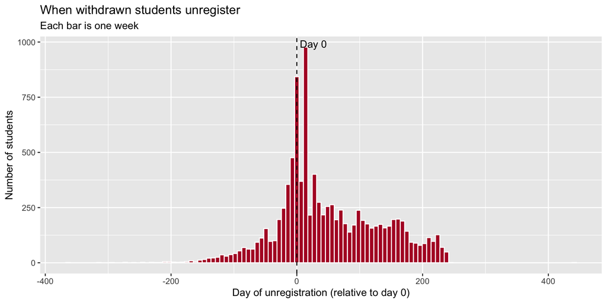

```r
# WHAT THIS CHUNK DOES: When students quit: before the start, in the first month, or later
# Withdrawn students with a recorded unregistration date
withdrawn <- master %>%
  filter(final_result == "Withdrawn", !is.na(date_unregistration))

ggplot(withdrawn, aes(x = date_unregistration)) +
  geom_histogram(binwidth = 7, fill = "#b2182b", colour = "white") +
  geom_vline(xintercept = 0, linetype = "dashed") +
  annotate("text", x = 5, y = Inf, label = "Day 0",
           hjust = 0, vjust = 1.5) +
  labs(title = "When withdrawn students unregister",
       subtitle = "Each bar is one week",
       x = "Day of unregistration (relative to day 0)",
       y = "Number of students")
```

```r
# Timing in periods, with the running total
withdrawn %>%
  mutate(period = cut(date_unregistration,
                      breaks = c(-Inf, 0, 30, 60, 90, 120, 180, Inf),
                      labels = c("On or before day 0", "Days 1-30", "Days 31-60",
                                 "Days 61-90", "Days 91-120", "Days 121-180",
                                 "After day 180"))) %>%
  count(period) %>%
  mutate(share      = percent(n / sum(n), 0.1),
         cumulative = percent(cumsum(n) / sum(n), 0.1)) %>%
  kable(caption = "When withdrawals happen")
```

When withdrawals happen

| period | n | share | cumulative |
| --- | --- | --- | --- |
| On or before day 0 | 3089 | 30.7% | 30.7% |
| Days 1-30 | 2030 | 20.2% | 50.9% |
| Days 31-60 | 1105 | 11.0% | 61.9% |
| Days 61-90 | 799 | 7.9% | 69.8% |
| Days 91-120 | 785 | 7.8% | 77.6% |
| Days 121-180 | 1501 | 14.9% | 92.5% |
| After day 180 | 754 | 7.5% | 100.0% |

```r
# Share of each module's withdrawals that happen on or before day 0
withdrawn %>%
  group_by(code_module) %>%
  summarise(withdrawals = n(),
            pct_on_or_before_day_0 = percent(mean(date_unregistration <= 0), 0.1)) %>%
  kable(caption = "Withdrawals on or before day 0, by module")
```

Withdrawals on or before day 0, by module

| code_module | withdrawals | pct_on_or_before_day_0 |
| --- | --- | --- |
| AAA | 126 | 15.9% |
| BBB | 2374 | 41.5% |
| CCC | 1947 | 25.6% |
| DDD | 2232 | 26.6% |
| EEE | 718 | 32.5% |
| FFF | 2377 | 29.0% |
| GGG | 289 | 23.5% |

10,063 of the 10,156 withdrawn students have an unregistration date; the other 93 are excluded from this timing analysis.

**Withdrawal is front-loaded.** 30.7% of withdrawals happen on or before day 0, and half (50.9%) have happened by day 30. By day 60, 61.9% of all withdrawals have already occurred. The problem is not mainly students giving up late in a long module; a large share leave before the module has started or within its first month.

There is also a smaller second wave between days 121 and 180 (14.9% of withdrawals), which is worth investigating further.

The share leaving on or before day 0 varies by module, from 15.9% in AAA to 41.5% in BBB. In BBB, more than two in five withdrawals happen before teaching begins.

**For the Board:** because so many withdrawals happen at or before the start, any effort that begins mid-module arrives too late for over half of the students it is meant to help. The window that matters most is enrollment through the first month.

# Part G1: Weekly activity by outcome

## 8. How students engage

This chart shows, for each outcome group, the average clicks per student in each week of the module.

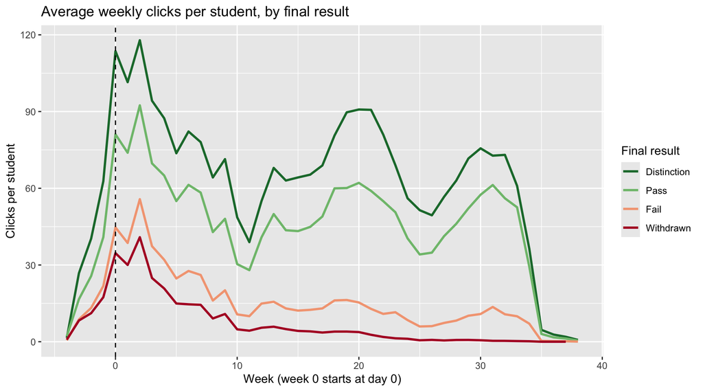

```r
# WHAT THIS CHUNK DOES: Average clicks per week for each result group
# Attach each student's final result to the click log (done once, reused below)
outcomes_dt <- as.data.table(master %>% select(all_of(k3), final_result))
outcomes_dt[, id_student := as.integer(id_student)]
vle_out <- studentVle[outcomes_dt, on = k3, nomatch = 0]

# Total clicks per outcome group per week
weekly <- vle_out[, .(clicks = sum(sum_click)),
                  by = .(final_result, week = floor(date / 7))] %>%
  as_tibble()

group_sizes <- master %>% count(final_result, name = "students")

weekly %>%
  left_join(group_sizes, by = "final_result") %>%
  mutate(clicks_per_student = clicks / students) %>%
  ggplot(aes(x = week, y = clicks_per_student, colour = final_result)) +
  geom_line(linewidth = 1) +
  geom_vline(xintercept = 0, linetype = "dashed") +
  scale_colour_manual(values = outcome_colours) +
  labs(title = "Average weekly clicks per student, by final result",
       x = "Week (week 0 starts at day 0)", y = "Clicks per student",
       colour = "Final result")
```

All four groups are most active in the first weeks, but the gap opens immediately. In week 0, a Withdrawn student averaged 34.7 clicks against 81.1 for a Pass student, and their activity then falls towards zero.

Failing students follow a slower version of the same path. In week 0 they were at about half the level of Pass students (44.7 vs 81.1 clicks); by week 24 they were at about a fifth (8.5 vs 40.4). They did not stop suddenly. They faded steadily, while Pass and Distinction students kept returning throughout the module.

# Part G2: The first two weeks and before the start

```r
# WHAT THIS CHUNK DOES: How clicks in the first 2 weeks (and before the start) relate to results
master <- master %>%
  mutate(
    early_clicks_band = cut(clicks_first_14_days,
                            breaks = c(-Inf, 0, 50, 150, Inf),
                            labels = c("0", "1-50", "51-150", "151+")),
    # Students who never clicked at all are kept as their own group; mixing them
    # into "No" would make pre-start activity look far more important than it is
    clicked_before_start = factor(case_when(
      never_clicked           ~ "Never clicked at all",
      clicks_before_start > 0 ~ "Yes",
      TRUE                    ~ "No, but clicked later"),
      levels = c("Yes", "No, but clicked later", "Never clicked at all"))
  )

# How many students fall in each band
master %>% count(early_clicks_band) %>%
  mutate(share = percent(n / sum(n), 0.1)) %>%
  kable(caption = "Students by clicks in days 0-13")
```

Students by clicks in days 0-13

| early_clicks_band | n | share |
| --- | --- | --- |
| 0 | 6168 | 18.9% |
| 1-50 | 9307 | 28.6% |
| 51-150 | 8640 | 26.5% |
| 151+ | 8478 | 26.0% |

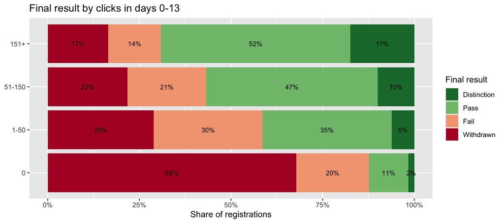

```r
plot_outcome(early_clicks_band, "clicks in days 0-13")
```

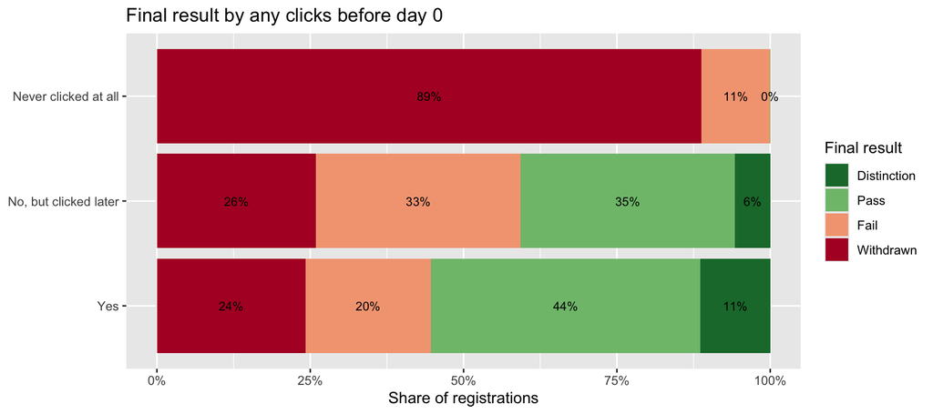

```r
plot_outcome(clicked_before_start, "any clicks before day 0")
```

Fixed bands are used rather than quartiles because 18.9% of students made no clicks at all in days 0-13; quartiles would split identical students into different groups.

**The first two weeks separate the groups clearly.** Of students with zero clicks in days 0-13 (6,168 students), 67.8% withdrew and only 12.4% completed. Among students with more than 150 clicks, withdrawal was 16.5% and 69.1% completed.

**Activity before the start matters much less than it first appears.** A simple Yes/No split suggests a big gap (24.2% vs 50.0% withdrawal), but the “No” group includes the 3,365 students who never clicked at all, 88.8% of whom withdrew. Comparing like with like, students who clicked before day 0 withdrew at 24.2% and students who first clicked after day 0 withdrew at 25.9%, almost the same. The real warning sign is never engaging at all, not the timing of the first click.

This is a description of what has already happened, not a prediction model: it shows that students who end up withdrawing were visibly disengaged from the very beginning.

# Part G3: Students who never engaged at all

```r
# WHAT THIS CHUNK DOES: What happened to students who never clicked at all
master %>%
  filter(never_clicked) %>%
  count(final_result) %>%
  mutate(share = percent(n / sum(n), 0.1)) %>%
  kable(caption = "Final result of students with zero clicks in the whole module")
```

Final result of students with zero clicks in the whole module

| final_result | n | share |
| --- | --- | --- |
| Pass | 3 | 0.1% |
| Fail | 374 | 11.1% |
| Withdrawn | 2988 | 88.8% |

3,365 registrations (10.3% of all) have no clicks at all in the click log. 88.8% of them withdrew and 11.1% failed. These students registered but never engaged with the module, so for them the problem sits entirely at the point of enrollment.

# Part G4: What students use

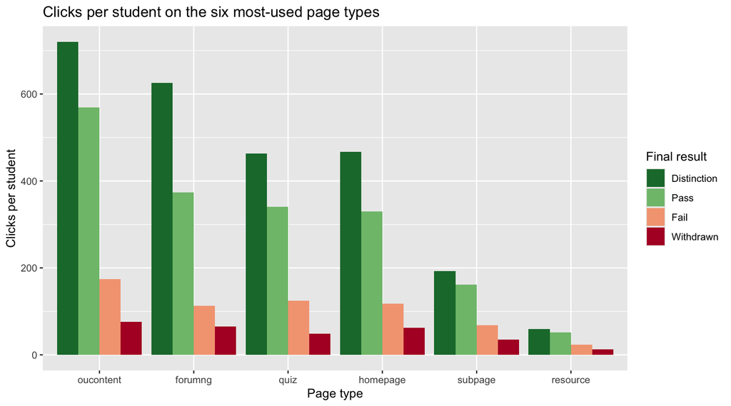

```r
# WHAT THIS CHUNK DOES: Which kinds of pages each group uses, and how much
# Clicks per page type per outcome group
site_clicks <- vle_out[, .(clicks = sum(sum_click)),
                       by = .(id_site, final_result)] %>%
  as_tibble() %>%
  left_join(vle %>% select(id_site, activity_type), by = "id_site")

activity <- site_clicks %>%
  group_by(activity_type, final_result) %>%
  summarise(clicks = sum(clicks), .groups = "drop") %>%
  left_join(group_sizes, by = "final_result") %>%
  mutate(clicks_per_student = clicks / students) %>%
  group_by(final_result) %>%
  mutate(share_of_group_clicks = clicks / sum(clicks)) %>%
  ungroup()

# The six most-used page types
top_types <- activity %>%
  group_by(activity_type) %>%
  summarise(total = sum(clicks)) %>%
  slice_max(total, n = 6) %>%
  pull(activity_type)

activity %>%
  filter(activity_type %in% top_types) %>%
  ggplot(aes(x = reorder(activity_type, -clicks), y = clicks_per_student,
             fill = final_result)) +
  geom_col(position = "dodge") +
  scale_fill_manual(values = outcome_colours) +
  labs(title = "Clicks per student on the six most-used page types",
       x = "Page type", y = "Clicks per student", fill = "Final result")
```

```r
# Share of each group's clicks going to each page type
activity %>%
  filter(activity_type %in% top_types) %>%
  select(activity_type, final_result, share_of_group_clicks) %>%
  mutate(share_of_group_clicks = percent(share_of_group_clicks, 0.1)) %>%
  pivot_wider(names_from = final_result, values_from = share_of_group_clicks) %>%
  kable(caption = "Share of each group's clicks by page type")
```

Share of each group’s clicks by page type

| activity_type | Distinction | Pass | Fail | Withdrawn |
| --- | --- | --- | --- | --- |
| forumng | 23.4% | 19.4% | 17.3% | 20.9% |
| homepage | 17.5% | 17.2% | 18.0% | 19.8% |
| oucontent | 27.0% | 29.6% | 26.8% | 24.1% |
| quiz | 17.4% | 17.7% | 19.1% | 15.4% |
| resource | 2.2% | 2.7% | 3.7% | 4.0% |
| subpage | 7.2% | 8.4% | 10.5% | 11.0% |

The page types are listed as they appear in the data (oucontent, forumng, quiz, homepage, subpage, resource); the data does not define them further.

The mix of what students use is broadly similar across all four groups. The difference is **volume, not type**: a Pass student averaged 568.7 clicks on oucontent pages compared with 75.7 for a Withdrawn student, about 7.5 times as many. The shares differ only moderately (oucontent is 29.6% of Pass clicks vs 24.1% of Withdrawn clicks). Troubled students use the platform in a somewhat different mix, but the main difference is that they use it far less.

# Part H1: The first assessment

## 9. Assessment behaviour

```r
# WHAT THIS CHUNK DOES: The first assignment: on time, late or missed, with a fair check on students still enrolled
# Was the first assessment submitted, and was it on time?
first_timing <- subs %>%
  semi_join(first_assess,
            by = c("code_module", "code_presentation", "id_assessment")) %>%
  transmute(code_module, code_presentation, id_student,
            # Banked results count as "On time": they were already passed earlier
            first_assessment = if_else(is_late, "Late", "On time"))

master <- master %>%
  select(-any_of("first_assessment")) %>%
  left_join(first_timing, by = k3) %>%
  mutate(first_assessment = factor(replace_na(first_assessment, "Not submitted"),
                                   levels = c("On time", "Late", "Not submitted")))

master %>% count(first_assessment) %>%
  mutate(share = percent(n / sum(n), 0.1)) %>%
  kable(caption = "First assessment of the module")
```

First assessment of the module

| first_assessment | n | share |
| --- | --- | --- |
| On time | 19069 | 58.5% |
| Late | 6316 | 19.4% |
| Not submitted | 7208 | 22.1% |

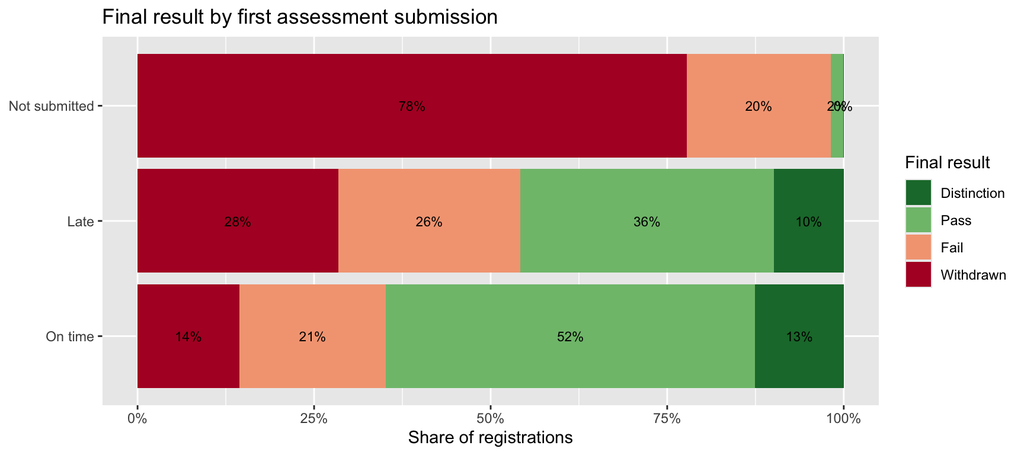

```r
plot_outcome(first_assessment, "first assessment submission")
```

```r
# Fair check: many students who "missed" the first assessment had already left
# before it was due, so missing it was a result of leaving, not a warning sign.
# Keep only students still registered on the first assessment's due date.
first_due <- non_exam %>%
  semi_join(first_assess, by = c("code_module", "code_presentation", "id_assessment")) %>%
  select(code_module, code_presentation, first_due_date = date)

master <- master %>%
  select(-any_of("first_due_date")) %>%
  left_join(first_due, by = c("code_module", "code_presentation")) %>%
  mutate(left_before_first_due = !is.na(date_unregistration) &
                                 date_unregistration <= first_due_date)

master %>%
  mutate(group = if_else(left_before_first_due,
                         "Had already left before it was due",
                         "Still registered on the due date")) %>%
  filter(first_assessment == "Not submitted") %>%
  count(group, name = "missed_first") %>%
  kable(caption = "Students who missed the first assessment")
```

Students who missed the first assessment

| group | missed_first |
| --- | --- |
| Had already left before it was due | 4405 |
| Still registered on the due date | 2803 |

```r
master %>%
  filter(!left_before_first_due) %>%
  group_by(first_assessment) %>%
  summarise(students        = n(),
            withdrawal_rate = percent(mean(final_result == "Withdrawn"), 0.1),
            completion_rate = percent(mean(completed_flag), 0.1)) %>%
  kable(caption = "First assessment and outcome: students still registered on its due date")
```

First assessment and outcome: students still registered on its due date

| first_assessment | students | withdrawal_rate | completion_rate |
| --- | --- | --- | --- |
| On time | 18852 | 13.4% | 65.6% |
| Late | 6196 | 27.1% | 46.7% |
| Not submitted | 2803 | 43.1% | 4.7% |

The first assessment is a clear dividing line. 7,208 registrations (22.1%) have no submission for their module’s first assessment; 77.8% of them withdrew and 20.4% failed, so only 1.8% completed.

**Care is needed here.** Many of these students had already unregistered before the first assessment was due, so for them missing it is a *result* of leaving, not a warning sign. The fairer comparison uses only students who were still registered on the due date. Among them, missing the first assessment is still a strong warning sign: 43.1% withdrew and only 4.7% completed, against 13.4% withdrawal and 65.6% completion for students who submitted on time. Of the 7,208 who missed it, 4,405 had already left and 2,803 were still registered.

Timing matters as well. Students who submitted the first assessment on time withdrew at 14.4%; those who submitted it after the listed date withdrew at 28.5%, nearly twice as often. Banked results are counted as on time, because they were passed in an earlier run.

# Part H2: How submission falls away over the module

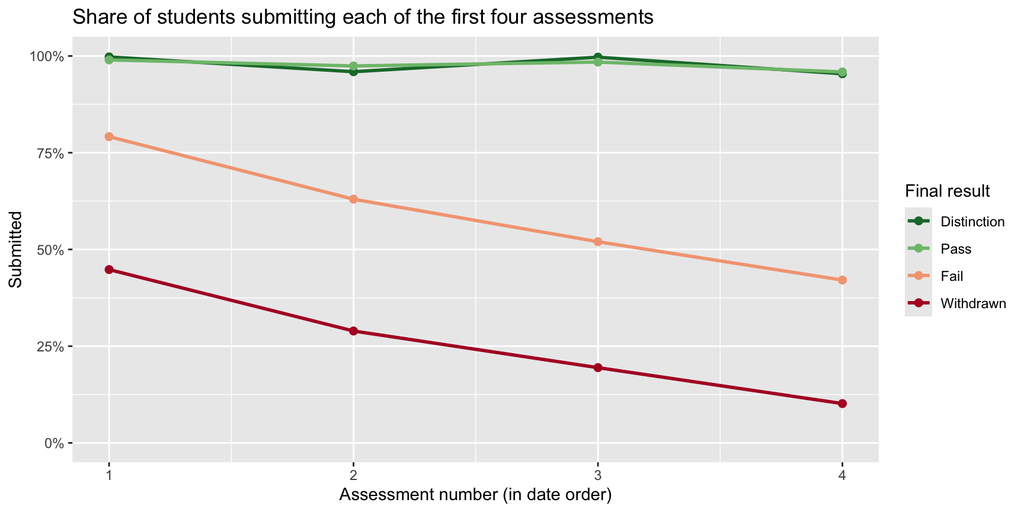

```r
# WHAT THIS CHUNK DOES: How hand-ins drop off across the first 4 assignments
# Number each module-run's non-exam assessments in date order
seq_assess <- non_exam %>%
  arrange(code_module, code_presentation, date, id_assessment) %>%
  group_by(code_module, code_presentation) %>%
  mutate(assessment_no = row_number()) %>%
  ungroup() %>%
  filter(assessment_no <= 4) %>%
  select(code_module, code_presentation, id_assessment, assessment_no)

# Every student x every one of their first four assessments: submitted or not
seq_assess %>%
  inner_join(master %>% select(all_of(k3), final_result),
             by = c("code_module", "code_presentation"),
             relationship = "many-to-many") %>%
  left_join(studentAssessment %>% select(id_assessment, id_student) %>%
              mutate(submitted = 1),
            by = c("id_assessment", "id_student")) %>%
  mutate(submitted = replace_na(submitted, 0)) %>%
  group_by(assessment_no, final_result) %>%
  summarise(submission_rate = mean(submitted), .groups = "drop") %>%
  ggplot(aes(x = assessment_no, y = submission_rate, colour = final_result)) +
  geom_line(linewidth = 1) +
  geom_point(size = 2) +
  scale_y_continuous(labels = percent, limits = c(0, 1)) +
  scale_colour_manual(values = outcome_colours) +
  labs(title = "Share of students submitting each of the first four assessments",
       x = "Assessment number (in date order)", y = "Submitted",
       colour = "Final result")
```

Pass and Distinction students submit almost every assessment (Pass: 99.0%, 97.4%, 98.4%, 95.9% across the first four). Failing students drop away one assessment at a time: 79.2%, then 63.0%, 52.0% and 42.1%. Withdrawn students fall faster still, from 44.8% to 10.2%.

# Part H3: What “Fail” actually looks like

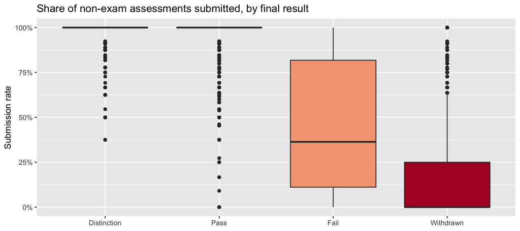

```r
# WHAT THIS CHUNK DOES: Show that failing students mostly stop handing work in, not score badly
# Distribution of submission rate and average score by outcome
ggplot(master, aes(x = final_result, y = submit_rate, fill = final_result)) +
  geom_boxplot(show.legend = FALSE) +
  scale_y_continuous(labels = percent) +
  scale_fill_manual(values = outcome_colours) +
  labs(title = "Share of non-exam assessments submitted, by final result",
       x = NULL, y = "Submission rate")
```

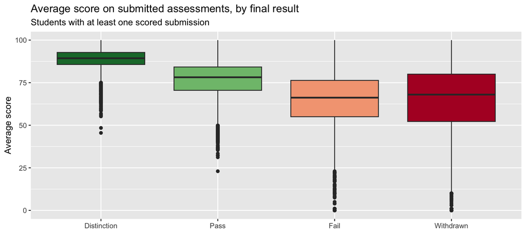

```r
ggplot(master %>% filter(!is.na(avg_score)),
       aes(x = final_result, y = avg_score, fill = final_result)) +
  geom_boxplot(show.legend = FALSE) +
  scale_fill_manual(values = outcome_colours) +
  labs(title = "Average score on submitted assessments, by final result",
       subtitle = "Students with at least one scored submission",
       x = NULL, y = "Average score")
```

```r
# Key facts about failing students
fail <- master %>% filter(final_result == "Fail")
pass_median <- median(master$avg_score[master$final_result == "Pass"], na.rm = TRUE)

tibble(
  measure = c("Failing students",
              "Submitted fewer than half of their assessments",
              paste0("Averaged at or above the Pass median score (",
                     round(pass_median, 1), ")")),
  value = c(comma(nrow(fail)),
            percent(mean(fail$submit_rate < 0.5), 0.1),
            percent(sum(fail$avg_score >= pass_median, na.rm = TRUE) / nrow(fail), 0.1))
) %>% kable(caption = "Failing students: submission versus score")
```

Failing students: submission versus score

| measure | value |
| --- | --- |
| Failing students | 7,052 |
| Submitted fewer than half of their assessments | 56.4% |
| Averaged at or above the Pass median score (78.2) | 17.3% |

```r
# Share of submissions made after the listed date
master %>%
  group_by(final_result) %>%
  summarise(pct_late = percent(sum(n_late) / sum(n_timed), 0.1)) %>%
  kable(caption = "Share of submissions made after the listed date")
```

Share of submissions made after the listed date

| final_result | pct_late |
| --- | --- |
| Distinction | 23.5% |
| Pass | 26.8% |
| Fail | 39.3% |
| Withdrawn | 42.5% |

The two boxplots show that the gap between Pass and Fail is much larger in **whether students submit** than in **how well they score**. The median failing student submitted 36.4% of their assessments, against 100% for the median Pass student, while median average scores were 66.2 and 78.2.

56.4% of failing students submitted fewer than half of their assessments, and 17.3% averaged at or above the median Pass score. In this data, a “Fail” is more often a student who stopped submitting than a student who submitted and scored poorly. Failing students’ submissions were also more often late (39.3% vs 26.8%; banked results are left out of this check).

**For the Board:** most failures look like a slower, quieter form of withdrawal. Recorded withdrawals (31.2%) understate how many students disengage; many of the 21.6% who fail had also largely stopped participating.

# Part H4: A data limitation to state clearly

```r
# WHAT THIS CHUNK DOES: Show that exam results exist only for modules CCC and DDD
studentAssessment %>%
  inner_join(assessments_clean %>% filter(assessment_type == "Exam"),
             by = "id_assessment") %>%
  count(code_module, name = "exam_submissions") %>%
  kable(caption = "Recorded exam submissions by module")
```

Recorded exam submissions by module

| code_module | exam_submissions |
| --- | --- |
| CCC | 1915 |
| DDD | 3044 |

Every module has at least one Exam in the assessments table, but exam submissions are recorded only for modules CCC and DDD. For this reason, exams are excluded from the assessment analysis above, and we do not draw conclusions from exam results.

# Part I1: Create the grouping columns

## 10. Where the problem concentrates

```r
# WHAT THIS CHUNK DOES: Make deprivation groups and the 4 engagement segments
master <- master %>%
  mutate(
    # Three broad deprivation groups (plus Unknown)
    deprivation_group = case_when(
      imd_band %in% c("0-10%", "10-20%", "20-30%")           ~ "0-30%",
      imd_band %in% c("30-40%", "40-50%", "50-60%", "60-70%") ~ "30-70%",
      imd_band == "Unknown"                                  ~ "Unknown",
      TRUE                                                   ~ "70-100%"),
    deprivation_group = factor(deprivation_group,
                               levels = c("0-30%", "30-70%", "70-100%", "Unknown")),
    # Engagement segments, built only from what students actually did
    engagement_segment = case_when(
      never_clicked      ~ "1. Never clicked",
      !submitted_first   ~ "2. Clicked, missed first assessment",
      submit_rate < 0.5  ~ "3. Submitted first, then fewer than half",
      TRUE               ~ "4. Submitted at least half")
  )
```

# Part I2: Workload and deprivation together

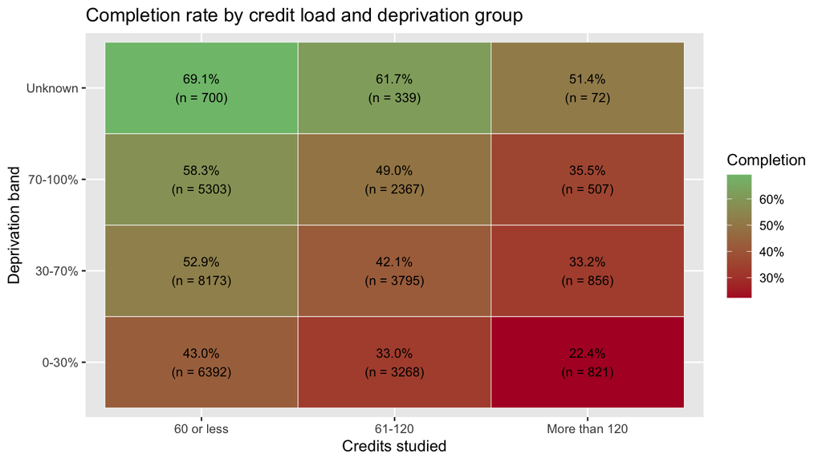

```r
# WHAT THIS CHUNK DOES: Completion by workload and deprivation together
master %>%
  group_by(deprivation_group, credit_group) %>%
  summarise(completion = mean(completed_flag), students = n(), .groups = "drop") %>%
  ggplot(aes(x = credit_group, y = deprivation_group, fill = completion)) +
  geom_tile(colour = "white") +
  geom_text(aes(label = paste0(percent(completion, 0.1), "\n(n = ", students, ")")),
            size = 3.2) +
  scale_fill_gradient(low = "#b2182b", high = "#7fbf7b", labels = percent) +
  labs(title = "Completion rate by credit load and deprivation group",
       x = "Credits studied", y = "Deprivation band", fill = "Completion")
```

The two factors add up. Within every deprivation group, completion falls as credit load rises; within every credit group, completion is lowest in the 0-30% band.

The weakest combination is the 0-30% band studying more than 120 credits: only 22.4% complete (821 students). The strongest group with a known band is 70-100% studying 60 credits or less: 58.3% complete.

Students with an Unknown band have the highest completion in every credit group (for example 69.1% at 60 credits or less). The data does not say why their band is missing, so we do not interpret this further.

# Part I3: Is the deprivation gap present in every module?

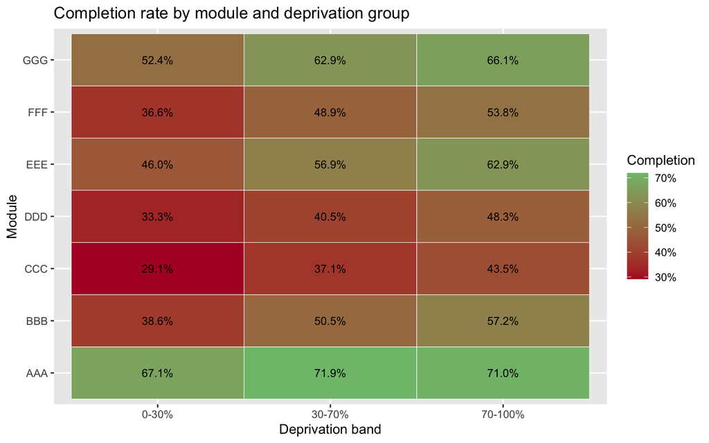

```r
# WHAT THIS CHUNK DOES: Completion by module and deprivation together
master %>%
  filter(deprivation_group != "Unknown") %>%
  group_by(code_module, deprivation_group) %>%
  summarise(completion = mean(completed_flag), students = n(), .groups = "drop") %>%
  ggplot(aes(x = deprivation_group, y = code_module, fill = completion)) +
  geom_tile(colour = "white") +
  geom_text(aes(label = percent(completion, 0.1)), size = 3.2) +
  scale_fill_gradient(low = "#b2182b", high = "#7fbf7b", labels = percent) +
  labs(title = "Completion rate by module and deprivation group",
       x = "Deprivation band", y = "Module", fill = "Completion")
```

# Part I4: Where the non-completers are

This is the most useful table for the Board. It groups every student by what they actually did, then shows where the non-completers sit.

```r
# WHAT THIS CHUNK DOES: Where the non-completers are, by engagement segment
segments <- master %>%
  group_by(engagement_segment) %>%
  summarise(students        = n(),
            completion_rate = mean(completed_flag),
            non_completers  = sum(!completed_flag),
            withdrawn       = sum(final_result == "Withdrawn"),
            failed          = sum(final_result == "Fail")) %>%
  mutate(share_of_students       = students / sum(students),
         share_of_non_completers = non_completers / sum(non_completers))

segments %>%
  mutate(across(c(completion_rate, share_of_students, share_of_non_completers),
                ~ percent(.x, 0.1))) %>%
  kable(caption = "Engagement segments")
```

Engagement segments

| engagement_segment | students | completion_rate | non_completers | withdrawn | failed | share_of_students | share_of_non_completers |
| --- | --- | --- | --- | --- | --- | --- | --- |
| 1. Never clicked | 3365 | 0.1% | 3362 | 2988 | 374 | 10.3% | 19.5% |
| 2. Clicked, missed first assessment | 3890 | 3.4% | 3759 | 2637 | 1122 | 11.9% | 21.8% |
| 3. Submitted first, then fewer than half | 5917 | 0.7% | 5878 | 3325 | 2553 | 18.2% | 34.2% |
| 4. Submitted at least half | 19421 | 78.3% | 4209 | 1206 | 3003 | 59.6% | 24.5% |

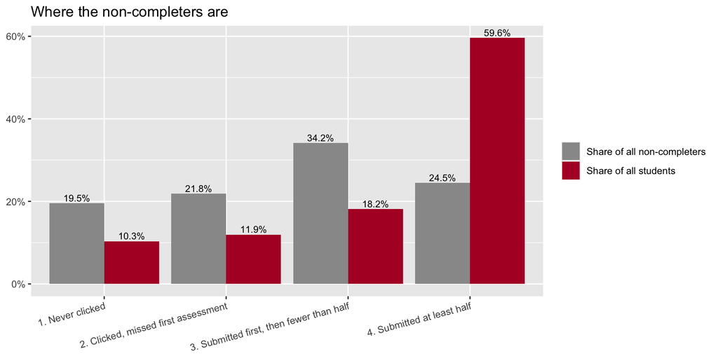

```r
segments %>%
  select(engagement_segment, share_of_students, share_of_non_completers) %>%
  pivot_longer(-engagement_segment, names_to = "measure", values_to = "share") %>%
  mutate(measure = recode(measure,
                          share_of_students = "Share of all students",
                          share_of_non_completers = "Share of all non-completers")) %>%
  ggplot(aes(x = engagement_segment, y = share, fill = measure)) +
  geom_col(position = "dodge") +
  geom_text(aes(label = percent(share, 0.1)),
            position = position_dodge(width = 0.9), vjust = -0.3, size = 3) +
  scale_y_continuous(labels = percent) +
  scale_fill_manual(values = c("grey60", "#b2182b")) +
  labs(title = "Where the non-completers are",
       x = NULL, y = NULL, fill = NULL) +
  theme(axis.text.x = element_text(angle = 15, hjust = 1))
```

Segments 1 to 3 are defined only by behaviour already visible in the data: no clicks, no first assessment, or fewer than half of assessments submitted. Together they are 40.4% of registrations but contain 75.5% of all non-completers (12,999 of 17,208), and almost none of them complete (0.1% to 3.4%).

Segment 3 is the largest single source of non-completion (34.2%). These students did submit their first assessment, so they started, and then drifted away. It contains 2,553 of the 7,052 failing students.

Among students who submitted at least half of their assessments, 78.3% complete.

**A caution on reading this table.** The segments are built from behaviour over the whole module, and withdrawing itself stops students clicking and submitting. So some students are in segments 1 to 3 *because* they withdrew, not the other way round (for example, 4,398 of the 5,606 withdrawn students who missed the first assessment had already unregistered before it was due). The table shows *where* non-completers sit, not what caused them to leave. The fair check in Part H1, which counts only students still registered on the due date, avoids this problem.

# Part I5: Does deprivation still matter once students engage?

```r
# WHAT THIS CHUNK DOES: Does the deprivation gap shrink once students engage?
master %>%
  filter(deprivation_group != "Unknown") %>%
  group_by(deprivation_group) %>%
  summarise(
    overall_completion       = percent(mean(completed_flag), 0.1),
    pct_in_segments_1_to_3   = percent(mean(engagement_segment !=
                                             "4. Submitted at least half"), 0.1),
    completion_in_segment_4  = percent(mean(completed_flag[engagement_segment ==
                                             "4. Submitted at least half"]), 0.1)
  ) %>%
  kable(caption = "Deprivation, engagement and completion")
```

Deprivation, engagement and completion

| deprivation_group | overall_completion | pct_in_segments_1_to_3 | completion_in_segment_4 |
| --- | --- | --- | --- |
| 0-30% | 38.3% | 48.5% | 73.4% |
| 30-70% | 48.4% | 39.1% | 78.7% |
| 70-100% | 54.2% | 34.4% | 81.7% |

Overall, the 0-30% band completes at 38.3% against 54.2% for the 70-100% band, a gap of 15.9 percentage points. Much of this gap is linked to engagement: 48.5% of the 0-30% band fall into the disengaged segments, compared with 34.4% of the 70-100% band. Among students who submitted at least half their assessments, the gap narrows to 8.3 points (73.4% vs 81.7%).

This is a description, not proof of cause, but it matters for the Board: the deprivation gap is largely a gap in early engagement, and engagement is something the university can act on.

# Part J: Innovation, a third group of students

## 11. The silent stayers

The official records put every student in one of two boxes: they either withdrew, or they stayed until the end. The click data shows there is a third group in between. These students never withdraw on paper, but they stop taking part long before the end. We call them **silent stayers** and look at them as a group of their own, because they need a different kind of help from students who quit.

# Part J1: Finding the silent stayers

For each student we find the **last day they clicked**, and show it as a share of the module’s length (0% = day 0, 100% = last day). A student is a **silent stayer** if they did **not** withdraw officially, but made no clicks at all in the second half of the module (or never clicked). Every student then falls into one of three segments:

- **Active stayers:** did not withdraw and were still active after halfway.
- **Silent stayers:** did not withdraw, but went silent before halfway.
- **Official quitters:** withdrew.

```r
# WHAT THIS CHUNK DOES: OUR INNOVATION: find the silent stayers (never quit, but went silent) and profile them
master <- master %>%
  mutate(
    last_active_pct = pmax(last_active_day, 0) / module_presentation_length,
    student_segment = factor(case_when(
      final_result == "Withdrawn"           ~ "Official quitters",
      never_clicked | last_active_pct < 0.5 ~ "Silent stayers",
      TRUE                                  ~ "Active stayers"),
      levels = c("Active stayers", "Silent stayers", "Official quitters"))
  )

segment_colours <- c("Active stayers" = "#2F6690", "Silent stayers" = "#E0A43A",
                     "Official quitters" = "#b2182b")

# Size and final result of each segment
master %>%
  group_by(student_segment) %>%
  summarise(students        = n(),
            share           = percent(n() / nrow(master), 0.1),
            ended_as_fail   = percent(mean(final_result == "Fail"), 0.1),
            completed       = percent(mean(completed_flag), 0.1)) %>%
  kable(caption = "Three segments of students")
```

Three segments of students

| student_segment | students | share | ended_as_fail | completed |
| --- | --- | --- | --- | --- |
| Active stayers | 19112 | 58.6% | 19.5% | 80.5% |
| Silent stayers | 3325 | 10.2% | 99.8% | 0.2% |
| Official quitters | 10156 | 31.2% | 0.0% | 0.0% |

```r
# How the three segments differ
master %>%
  group_by(student_segment) %>%
  summarise(
    median_last_click       = percent(median(pmin(last_active_pct, 1), na.rm = TRUE), 1),
    submitted_first         = percent(mean(submitted_first), 0.1),
    average_score           = round(mean(avg_score, na.rm = TRUE), 1),
    more_than_120_credits   = percent(mean(studied_credits > 120), 0.1),
    repeat_attempt          = percent(mean(num_of_prev_attempts > 0), 0.1),
    below_A_level           = percent(mean(highest_education %in%
                                           c("No Formal quals", "Lower Than A Level")), 0.1),
    most_deprived_0_30      = percent(mean(deprivation_group == "0-30%"), 0.1)) %>%
  kable(caption = "Profile of the three segments")
```

Profile of the three segments

| student_segment | median_last_click | submitted_first | average_score | more_than_120_credits | repeat_attempt | below_A_level | most_deprived_0_30 |
| --- | --- | --- | --- | --- | --- | --- | --- |
| Active stayers | 95% | 98.4% | 76.1 | 4.9% | 10.7% | 36.4% | 27.9% |
| Silent stayers | 21% | 60.9% | 64.8 | 5.1% | 19.7% | 53.7% | 40.7% |
| Official quitters | 20% | 44.8% | 64.1 | 11.4% | 14.5% | 47.0% | 37.4% |

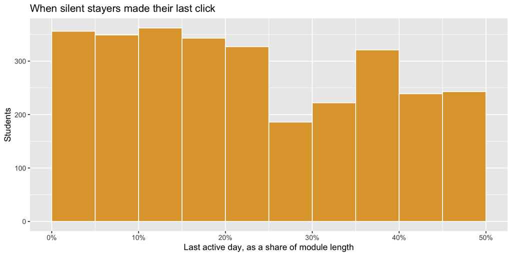

```r
# When do silent stayers go quiet?
master %>%
  filter(student_segment == "Silent stayers", !never_clicked) %>%
  ggplot(aes(x = last_active_pct)) +
  geom_histogram(binwidth = 0.05, boundary = 0, fill = "#E0A43A", colour = "white") +
  scale_x_continuous(labels = percent, limits = c(0, 0.5)) +
  labs(title = "When silent stayers made their last click",
       x = "Last active day, as a share of module length", y = "Students")
```

```r
# Silent stayers by module
master %>%
  group_by(code_module) %>%
  summarise(silent_stayers = sum(student_segment == "Silent stayers"),
            share_of_module = percent(mean(student_segment == "Silent stayers"), 0.1)) %>%
  kable(caption = "Silent stayers by module")
```

Silent stayers by module

| code_module | silent_stayers | share_of_module |
| --- | --- | --- |
| AAA | 21 | 2.8% |
| BBB | 919 | 11.6% |
| CCC | 317 | 7.1% |
| DDD | 582 | 9.3% |
| EEE | 309 | 10.5% |
| FFF | 784 | 10.1% |
| GGG | 393 | 15.5% |

**A group the official figures do not show.** 3,325 registrations (10.2%) are silent stayers. Almost all of them (3,317, or 99.8%) end with a **Fail** on their record. They are 47% of all failing students.

**They are not the same as students who quit.** Official quitters mostly leave at the front door (Part F3), and heavy workload is strongly linked to quitting. Silent stayers look different:

- **They start.** 61% handed in the first assignment (against 45% of quitters).
- **Their work was decent.** Their average score before going quiet was 64.8, similar to other non-completers, and two thirds averaged 60 or more.
- **They fade mid-course.** The typical silent stayer made their last click about a fifth of the way through the module (around day 53, roughly week 8).
- **Workload is not their problem.** Only 5.1% take more than 120 credits, the same as active stayers and half the rate of quitters.
- **They are more often repeat students (19.7%), below A level (53.7%) and from the most deprived areas (40.7%)** than active stayers (10.7%, 36.4% and 27.9%).
- **It varies by module:** from 2.8% of students in AAA to 15.5% in GGG.

**A different retention strategy.** Because silent stayers are still registered, the university can still reach them, and because they had started well, the problem is not ability. We suggest a strategy aimed at them, separate from the one for quitters:

|  | Official quitters | Silent stayers |
| --- | --- | --- |
| When they are lost | Before the start and in the first month | Mid-course, around week 8 |
| What stands out | Never engage; heavy workload | Started well, then faded; more repeat, less-qualified and deprived students |
| Strategy | **Fix the front door**: contact non-starters by day 30, workload advice at sign-up | **Re-engage in the middle**: act on silence while they are still enrolled |
| Concrete actions | Welcome call; workload check above 120 credits | A tutor contacts any student silent for 3 weeks; a catch-up plan or deadline extension; the option to pause and move to the next presentation instead of failing; study-skills and peer support |

*Interpretation, not proof:* the data shows what these students did, not why. The profile suggests that confidence, study skills or life events matter more than workload for this group, but the university would need to ask them to be sure.

*Limitation:* “no clicks after halfway” is a simple cut-off chosen for this report. A student could still study offline, so this is a measure of lost contact with the university, not proof that the student stopped studying.

# Answer to the Board

## 12.1 Key figures

```r
# WHAT THIS CHUNK DOES: One summary table of the headline numbers for the Board
tibble(
  measure = c("Registrations analysed",
              "Completed (Pass or Distinction)",
              "Withdrawn",
              "Silent stayers (did not withdraw, silent before halfway)",
              "Withdrawal rate, 2013J vs 2014J",
              "Same, only modules that ran in both years",
              "Withdrawals on or before day 0",
              "Withdrawals by day 30",
              "Registrations with no clicks at all",
              "Registrations that missed the first assessment",
              "Non-completers found in engagement segments 1-3"),
  value = c(
    comma(nrow(master)),
    percent(mean(master$completed_flag), 0.1),
    percent(mean(master$final_result == "Withdrawn"), 0.1),
    percent(mean(master$student_segment == "Silent stayers"), 0.1),
    paste(percent(mean(master$final_result[master$code_presentation == "2013J"] == "Withdrawn"), 0.1),
          "vs",
          percent(mean(master$final_result[master$code_presentation == "2014J"] == "Withdrawn"), 0.1)),
    paste(percent(mean(master$final_result[master$code_presentation == "2013J" &
                                           master$code_module %in% both_years] == "Withdrawn"), 0.1),
          "vs",
          percent(mean(master$final_result[master$code_presentation == "2014J" &
                                           master$code_module %in% both_years] == "Withdrawn"), 0.1)),
    percent(mean(withdrawn$date_unregistration <= 0), 0.1),
    percent(mean(withdrawn$date_unregistration <= 30), 0.1),
    percent(mean(master$never_clicked), 0.1),
    percent(mean(master$first_assessment == "Not submitted"), 0.1),
    percent(sum(!master$completed_flag &
                master$engagement_segment != "4. Submitted at least half") /
            sum(!master$completed_flag), 0.1))
) %>% kable(caption = "Key figures for the Board")
```

Key figures for the Board

| measure | value |
| --- | --- |
| Registrations analysed | 32,593 |
| Completed (Pass or Distinction) | 47.2% |
| Withdrawn | 31.2% |
| Silent stayers (did not withdraw, silent before halfway) | 10.2% |
| Withdrawal rate, 2013J vs 2014J | 26.8% vs 34.0% |
| Same, only modules that ran in both years | 26.8% vs 31.4% |
| Withdrawals on or before day 0 | 30.7% |
| Withdrawals by day 30 | 50.9% |
| Registrations with no clicks at all | 10.3% |
| Registrations that missed the first assessment | 22.1% |
| Non-completers found in engagement segments 1-3 | 75.5% |

## 12.2 What kind of institution are we?

The Board has treated the loss of roughly a third of registrations as the price of an open-access mission. The data does not support the idea that this loss is spread evenly or is unavoidable. It shows an institution where:

1. **Fewer than half of registrations complete.** 47.2% end in Pass or Distinction, and withdrawal is rising in six of the seven modules. The headline rise (26.8% in 2013J to 34.0% in 2014J) is partly due to CCC joining in 2014; on the same modules it is 26.8% to 31.4%.
2. **Students are lost at the front door.** 30.7% of withdrawals happen on or before day 0 and half by day 30. 10.3% of registrations never click once.
3. **“Fail” is mostly a quieter form of withdrawal.** Failing students typically stop submitting work (56.4% submitted fewer than half) rather than submit and score poorly. A third segment, the **silent stayers** (10.2%), never withdraw but go quiet around week 8; almost all of them end with a Fail.
4. **The problem is concentrated.** Students who never engaged, missed the first assessment, or submitted fewer than half of their assessments are 40.4% of registrations but 75.5% of all non-completers. (Some of these students are in these groups because they had already withdrawn, so this shows where losses sit, not what caused them.)
5. **Who a student is matters less than what they do.** Every background factor is only weakly linked to outcomes. The strongest (credit load, repeat attempts and module) are practically tied, and two of them, workload and module, are things the university controls. Gender shows almost no link.
6. **Disadvantage and overload compound.** The 0-30% deprivation band studying more than 120 credits completes at 22.4%. Much of the deprivation gap is linked to early engagement: among students who stayed engaged, the gap narrows from 15.9 to 8.3 percentage points.

In short: Meridian is not an institution where students fail at random. It is an institution that loses a large share of students before or soon after they start, and whose healthy students are clearly visible by what they do in the first weeks.

## 12.3 Where to focus in 2016

Each focus area below follows directly from the findings. The data shows *where* the problem is; it cannot show which specific actions will work, so each should be introduced in a way that allows its effect to be measured.

1. **The period from registration to day 30.** This is where half of all withdrawals happen. The key target is the 10.3% of registrations who never click at all: 88.8% of them withdraw. (The timing of the first click matters little; students who first clicked before or after day 0 withdrew at similar rates, 24.2% vs 25.9%.)
2. **The first assessment as a checkpoint.** Among students still registered on its due date, those who missed it completed at only 4.7%, against 65.6% for students who submitted on time. A missed or late first assessment is a clear, early point at which to follow up.
3. **Students who start and then drift away.** Segment 3 is the largest single source of non-completion (34.2%). Missed submissions should be treated as a sign of disengagement, and “Fail” and “Withdrawn” should be reported together as disengagement rather than as separate problems.
4. **Credit load at enrolment.** Withdrawal rises from 25.4% at 60 credits or less to 51.3% above 120 credits. Students taking heavy loads, especially in the 0-30% band, should be advised on workload when they enrol.
5. **A review of specific modules.** CCC (44.5% withdrawal) and DDD (35.9%) need review, along with BBB, where 41.5% of withdrawals happen on or before day 0, and GGG, where withdrawal more than doubled (6.9% to 16.8%).
6. **Better data.** Exam results are recorded only for CCC and DDD, 1,111 registrations have no deprivation band, and reasons for withdrawal are not recorded. Filling these gaps would make the 2016 picture more complete.
7. **Re-engage the silent stayers (Part J).** They need a different strategy from quitters: a tutor contacts any student silent for 3 weeks, offers a catch-up plan or deadline extension, and the option to pause and move to the next presentation instead of failing. Report silent stayers as their own figure each year.

## 12.4 Limitations

- This is a descriptive analysis. It shows associations, not proof of cause.
- Exam results are available only for modules CCC and DDD, so exams were excluded from the assessment analysis.
- The data does not define page types (such as oucontent) or assessment types (TMA, CMA), so they are reported by their labels only.
- The direction of the deprivation bands and the meaning of day 0 are assumptions, stated in Section 4.
- 93 withdrawn students have no unregistration date and are excluded from the timing analysis.
- The data covers 22 module-runs across 2013 and 2014 only.
- 1,909 assessment results were banked (carried over from an earlier run). They count as submitted, but are left out of the late / on-time checks.
- Withdrawing stops students clicking and submitting, so the engagement segments partly reflect withdrawal rather than predict it. The fair check in Part H1 only uses students who were still registered at the time.
- The “no clicks after halfway” cut-off for silent stayers is a simple rule chosen for this report; a student could still study offline.
- As the Board asked, this report describes the present data. It is not a forecast or an early-warning model. The traffic light in the appendix is only an idea for later, and is not part of our answer.

## 12.5 Conclusion

The Board’s question was what kind of institution Meridian is. The answer from the data is an institution whose completion problem is **early, visible and concentrated** rather than spread evenly across its students. That makes 2016 a question of where to act first, and the data points clearly to enrolment, the first month, and the first assessment. Silent stayers need a second, mid-course strategy: re-engaging students who started well and then went quiet.

# Appendix: a next step beyond this brief

## A day-14 “traffic light” for every student

**Please note:** the Board asked for a picture of the present data, “not a forecast, not an early-warning model”. This appendix is therefore **not part of our answer** to the Board. It is offered only as an idea for after the 2016 plan is set, to show how the findings above could later be turned into a practical tool.

Most of the warning signs above are only known late in the module, or are partly a result of withdrawing. A student support team needs something it can use **early**. So this traffic light uses only four facts that are already known by **day 14**:

1. **Low early activity:** fewer than 50 clicks in days 0-13.
2. **Heavy workload:** studying more than 120 credits.
3. **Repeat attempt:** has tried the module before.
4. **Low prior education:** no formal qualifications, or below A level.

Each student gets one point per warning sign: **Green** = 0, **Amber** = 1, **Red** = 2 or more. To keep the test fair, only students still registered on day 14 are included, because students who had already left cannot be helped by a day-14 check.

```r
# WHAT THIS CHUNK DOES: APPENDIX, outside the brief: an idea for later, a day-14 Green/Amber/Red check
traffic <- master %>%
  # Only students who had not left by day 14
  filter(is.na(date_unregistration) | date_unregistration > 14) %>%
  mutate(
    flag_low_activity = clicks_first_14_days < 50,
    flag_heavy_load   = studied_credits > 120,
    flag_repeat       = num_of_prev_attempts > 0,
    flag_low_prior_ed = highest_education %in% c("No Formal quals", "Lower Than A Level"),
    warning_points    = flag_low_activity + flag_heavy_load + flag_repeat + flag_low_prior_ed,
    traffic_light     = factor(case_when(warning_points == 0 ~ "Green",
                                         warning_points == 1 ~ "Amber",
                                         TRUE                ~ "Red"),
                               levels = c("Green", "Amber", "Red"))
  )

# How each colour turned out
traffic_summary <- traffic %>%
  group_by(traffic_light) %>%
  summarise(students        = n(),
            withdrawal_rate = mean(final_result == "Withdrawn"),
            completion_rate = mean(completed_flag),
            non_completers  = sum(!completed_flag)) %>%
  mutate(share_of_students       = students / sum(students),
         share_of_non_completers = non_completers / sum(non_completers))

traffic_summary %>%
  mutate(across(c(withdrawal_rate, completion_rate, share_of_students,
                  share_of_non_completers), ~ percent(.x, 0.1))) %>%
  kable(caption = "Day-14 traffic light: how each group turned out")
```

Day-14 traffic light: how each group turned out

| traffic_light | students | withdrawal_rate | completion_rate | non_completers | share_of_students | share_of_non_completers |
| --- | --- | --- | --- | --- | --- | --- |
| Green | 9053 | 14.4% | 71.7% | 2565 | 32.2% | 20.1% |
| Amber | 11712 | 20.7% | 53.7% | 5419 | 41.7% | 42.6% |
| Red | 7354 | 26.7% | 35.4% | 4750 | 26.2% | 37.3% |

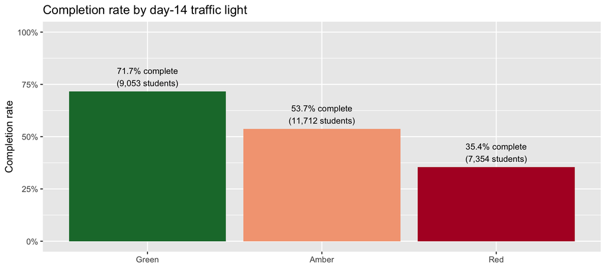

```r
traffic_summary %>%
  ggplot(aes(x = traffic_light, y = completion_rate, fill = traffic_light)) +
  geom_col(show.legend = FALSE) +
  geom_text(aes(label = paste0(percent(completion_rate, 0.1), " complete\n(",
                               comma(students), " students)")),
            vjust = -0.3, size = 3.2) +
  scale_fill_manual(values = c(Green = "#1b7837", Amber = "#f4a582", Red = "#b2182b")) +
  scale_y_continuous(labels = percent, limits = c(0, 1)) +
  labs(title = "Completion rate by day-14 traffic light",
       x = NULL, y = "Completion rate")
```

**The traffic light sorts students clearly by day 14.** Among the 28,119 students still registered on day 14:

- **Green** students (no warning signs, 32.2% of students) completed at **71.7%**.
- **Amber** students (one sign, 41.7%) completed at **53.7%**.
- **Red** students (two or more signs, 26.2%) completed at only **35.4%**, and withdrew almost twice as often as Green students (26.7% vs 14.4%).

Red students are 26.2% of students but 37.3% of all non-completers, so a support team that starts with Red students is working where the losses are highest.

**If the university wants to go further later:** this check would need no new data and no complex model. Every fact it uses is already in the university’s systems by day 14, so it could be run as a simple weekly report once the 2016 plan is agreed.

*Limitations:* the four signs and their cut-offs were chosen from this same data, so the rule should be tried on the 2015 presentations before it is relied on. It also misses many students (20.1% of non-completers are Green), so it is a way to prioritise, not a way to decide who needs help.